# R Notebook

```r
suppressPackageStartupMessages({
  library(dplyr)
  library(webchem)
  library(circlize)
  library(ggplot2)
  library(pheatmap)
})
```

Import the file mapping terms in the GEO datasets to a common term for the TERM, TBC, and MIATE reporting standards. The file was created through manual curation.

```r
TermSynonyms <- read.delim('TermsMapped.txt', sep = '\t', header = T)
```

Import the metadata from the GEO datasets

```r
GEO_data <- read.delim('GEO_CharacteristicExtracted5.txt', sep = '\t', header = F)
colnames(GEO_data) <- c('mat', 'channel', 'index', 'value')
```

Create a merged dataset that combines the key mapping with original metadata.

```r
merged.data <- merge(GEO_data, TermSynonyms, by.x = 'index', by.y = 'TermName')
term.table <- table(merged.data$mat, merged.data$TermSynonym)
term.table[which(term.table > 0)] <- 1
```

Calculate the number of RS terms present in each dataset and filter the 10 datasets with the most identifiable number of metadata terms.

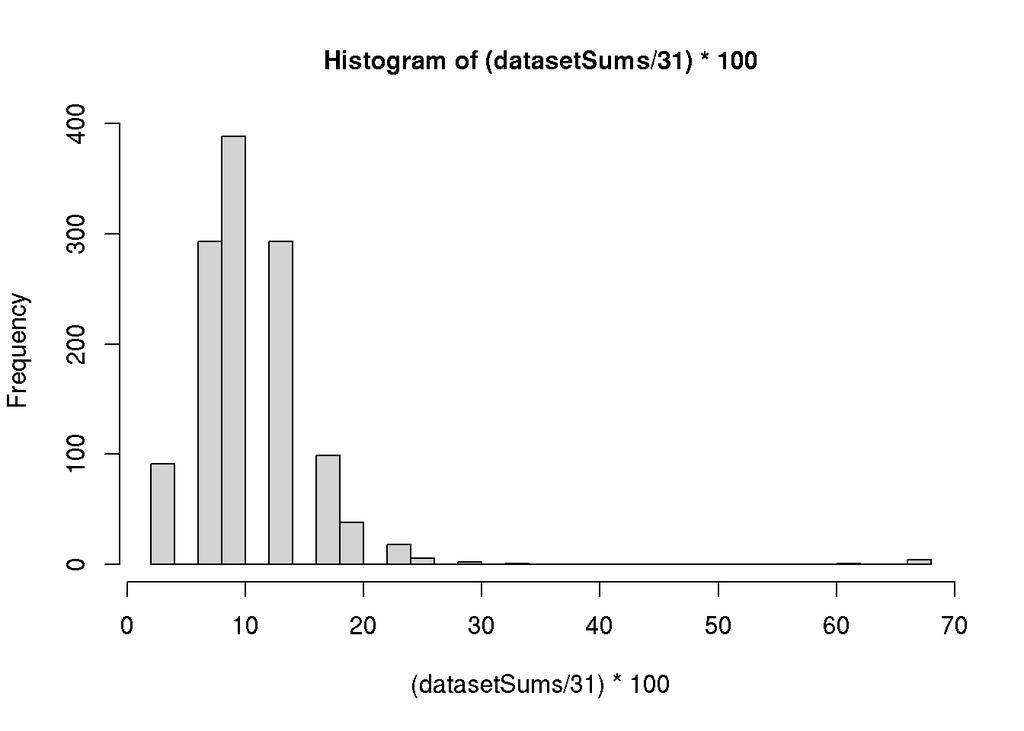

```r
datasetSums <- rowSums(term.table)
hist((datasetSums/31)*100, breaks = 31)
```

```r
top10 <- data.frame(term.table[names(datasetSums[order(-datasetSums)][1:10]), ])
```

Calculate the number of datasets reporting each RS term.

```r
termSums <- colSums(term.table)
df.term <- data.frame(
  term_name = names(termSums),
  term_count = (termSums/length(unique(GEO_data[,1])))*100
)
```

Map the dataset terms to a common term.

```r
df.term <- merge(df.term, unique(TermSynonyms[,c(2,3)]), by.x = 'term_name', by.y = 'TermSynonym', all = TRUE)
df.term$GROUP <- factor(df.term$GROUP, level = c(
  "TERM + TBC + MIATE",
  "TERM + MIATE",
  "TERM + TBC",
  "TBC + MIATE",
  "TERM",
  "TBC",
  "MIATE"
))
df.term <- df.term[order(df.term$GROUP, -df.term$term_count),]
df.term$term_name <- factor(df.term$term_name, levels = df.term$term_name)
df.term[is.na(df.term)] <- 0
```

Show a histogram of the number of datasets reporting RS terms.

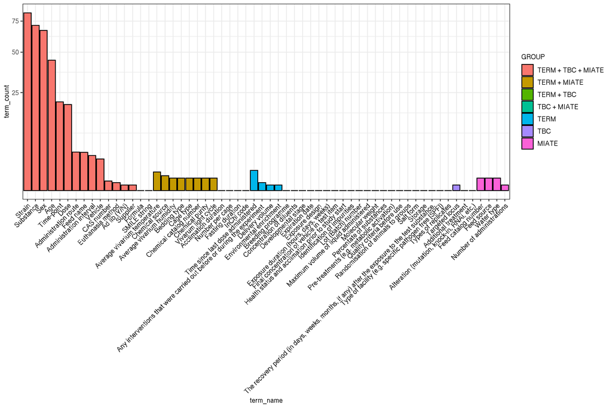

```r
#cairo_pdf(filename = 'MIATE_barplot_comparison.pdf', height = 9, width = 12)
  ggplot(data = df.term, aes(x = term_name, y = term_count, fill = GROUP)) +
    geom_bar(stat = 'identity', color = 'black') +
    scale_y_continuous(trans='sqrt') +
    theme_bw() +
    theme(axis.text.x = element_text(angle = 45, vjust = 1, hjust=1, colour = 'black'))
```

```r
#dev.off()
```

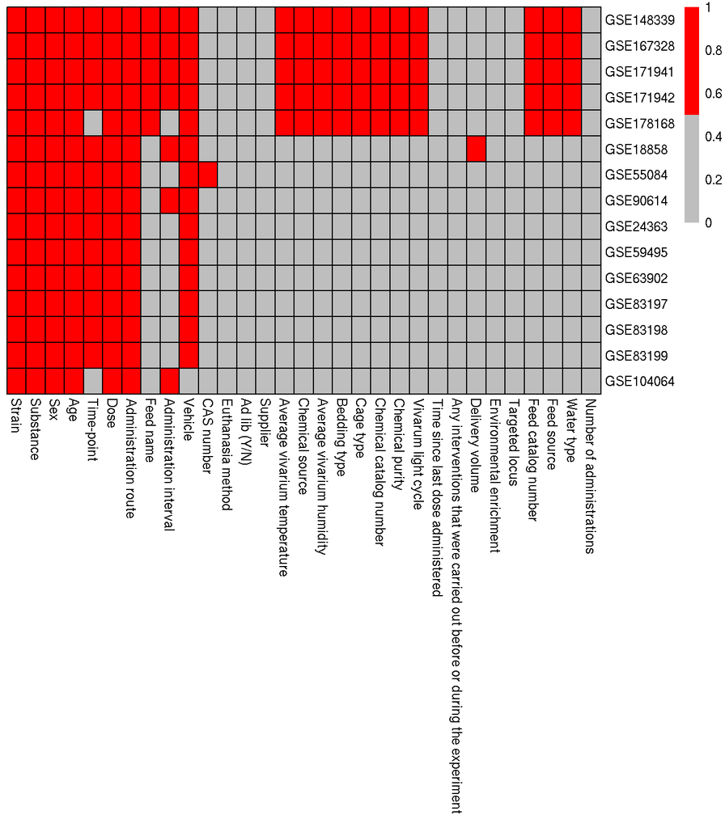

```r
o <- intersect(df.term$term_name, colnames(term.table))
filtered.term.table <- term.table[names(datasetSums[order(-datasetSums)][1:15]), o]
rownames(filtered.term.table) <- gsub('_series_matrix.txt', '', rownames(filtered.term.table))
#cairo_pdf(filename = 'MIATE_HM_comparison.pdf', height = 9, width = 12)
  pheatmap(filtered.term.table, cluster_rows = FALSE, cluster_cols = FALSE, color = c('grey', 'red'), border_color = 'black')
```

```r
#dev.off()
```

Identify the values reporting for a RS term. Here strain is used as an example.

```r
strain <- unique(
  toupper(
  trimws(merged.data %>% filter(TermSynonym == 'Strain') %>% pull(value),
         which = c('both'), whitespace = "[ \t\r\n]"
         )
  )
  )
strain <- strain[order(strain)]

strain[1:100]
```

```
##   [1] " HAN WISTAR [CRL:WI(HAN)]"
##   [2] "129/SV"
##   [3] "129/SVIM"
##   [4] "129/SVJ"
##   [5] "129P2/OLAHSD"
##   [6] "129P2/OLAHSD/C57BL/6"
##   [7] "129S1/SVIMJ"
##   [8] "129S1/SVIMJ (S1)"
##   [9] "129S1/SVLMJ"
##  [10] "129S4/SVJAE-PPARATM1GONZ/J"
##  [11] "129SVEV/C57BL6/J MIXED"
##  [12] "A/HEJ"
##  [13] "A/J"
##  [14] "AKR/J"
##  [15] "AN OUTBRED HSD: SPRAGUE DAWLEY"
```

[output cut: 85 more lines]

Automated mapping of chemical names to CAS and SMILES identifiers.

```r
substance <- unique(
  toupper(
  trimws(merged.data %>% filter(TermSynonym == 'Substance') %>% pull(value),
         which = c('both'), whitespace = "[ \t\r\n]"
         )
  )
  )
substance <- substance[!grepl('DAYS', substance)]
substance <- substance[!grepl('/KG', substance)]
substance <- substance[!grepl('%', substance)]
substance <- substance[!grepl(' LIGHT', substance)]
substance <- substance[!grepl(' HOURS', substance)]
substance <- substance[!grepl(' EXPOSURE', substance)]
substance <- substance[!grepl('PERCENT', substance)]
substance <- substance[order(substance)]
batch_query_cas <- cir_query(substance, representation = c('cas'), match = 'first', verbose = FALSE)
batch_query_name <- cir_query(substance, representation = c('names'), match = 'first', verbose = FALSE)
batch_query_smiles <- cir_query(substance, representation = c('smiles'), match = 'first', verbose = FALSE)
combined.cas <- t(bind_rows(batch_query_cas, .id = "substance"))
combined.name <- t(bind_rows(batch_query_name, .id = "substance"))
combined.smiles <- t(bind_rows(batch_query_smiles, .id = "substance"))

mm <- cbind(combined.cas, combined.name, combined.smiles)
```

Calculate the number of matches for chemical identifiers.

```r
cas.match <- sum(!is.na(batch_query_cas))/length(batch_query_cas)*100
name.match <- sum(!is.na(batch_query_name))/length(batch_query_cas)*100
smiles.match <- sum(!is.na(batch_query_smiles))/length(batch_query_cas)*100
```